# Device Classification

Rishi Shanthan Bhagavatham

```
Notes on R:
-   For the elastic net model, what we called λ in the videos, glmnet calls “alpha”; you can get a range of results by varying alpha from 1 (lasso) to 0 (ridge regression) [and, of course, other values of alpha in between].

-   In a function call like glmnet(x,y,family=”mgaussian”,alpha=1) the predictors x need to be in R’s matrix format, rather than data frame format.  You can convert a data frame to a matrix using as.matrix – for example, x <- as.matrix(data[,1:n-1])

- Rather than specifying a value of T, glmnet returns models for a variety of values of T.
```

```r
library(ISLR2)
library(ggplot2)
library(MASS)
library(car)
library(class)
```

# Question: Used Phones & Tablets Pricing Dataset

The used and refurbished device market has grown considerably over the past decade as it provide cost-effective alternatives to both consumers and businesses that are looking to save money when purchasing one. Maximizing the longevity of devices through second-hand trade also reduces their environmental impact and helps in recycling and reducing waste. Here is a sample dataset of normalized used and new pricing data of refurbished / used devices.

- device_brand: Name of manufacturing brand
- os: OS on which the device runs
- screen_size: Size of the screen in cm
- 4g: Whether 4G is available or not
- 5g: Whether 5G is available or not
- front_camera_mp: Resolution of the rear camera in megapixels
- back_camera_mp: Resolution of the front camera in megapixels
- internal_memory: Amount of internal memory (ROM) in GB
- ram: Amount of RAM in GB
- battery: Energy capacity of the device battery in mAh
- weight: Weight of the device in grams
- release_year: Year when the device model was released
- days_used: Number of days the used/refurbished device has been used
- normalized_new_price: Normalized price of a new device of the same model
- normalized_used_price (response variable): Normalized price of the used/refurbished device

Read the data and answer the questions below:

```r
# Loading of the data
set.seed(100)
used_devices= read.csv("used_device_data.csv", header=TRUE, sep=",")

used_devices$device_brand=as.factor(used_devices$device_brand)
used_devices$os=as.factor(used_devices$os)
used_devices$X4g=as.factor(used_devices$X4g)
used_devices$X5g=as.factor(used_devices$X5g)

#Dividing the dataset into training and testing datasets
testRows = sample(nrow(used_devices),0.2*nrow(used_devices))
testData = used_devices[testRows, ]
trainData = used_devices[-testRows, ]
row.names(trainData) <- NULL
head(trainData)
```

```
##   device_brand      os screen_size X4g X5g rear_camera_mp front_camera_mp
## 1        Honor Android       14.50 yes  no             13               5
## 2        Honor Android       16.69 yes yes             13               8
## 3        Honor Android       15.32 yes  no             13               8
## 4        Honor Android       16.23 yes  no             13               8
## 5        Honor Android       13.84 yes  no              8               5
## 6        Honor Android       15.77 yes  no             13               8
##   internal_memory ram battery weight release_year days_used
## 1              64   3    3020    146         2020       127
## 2             128   8    4200    213         2020       162
## 3              64   3    5000    185         2020       293
## 4              64   4    4000    176         2020       223
## 5              32   2    3020    144         2020       234
## 6              64   4    3400    164         2020       219
##   normalized_new_price normalized_used_price
## 1             4.715100              4.307572
## 2             5.884631              5.111084
## 3             4.947837              4.389995
## 4             5.060694              4.413889
## 5             4.518958              3.878259
## 6             5.188726              4.729421
```

## Part 1 [9 pts]: EXPLORATORY DATA ANALYSIS

a). (3 pts) Using trainData, create a boxplot of response variable “normalized_used_price” and “os”, with “normalized_used_price” on the vertical axis. Interpret the plot.Which os devices are the most expensive?

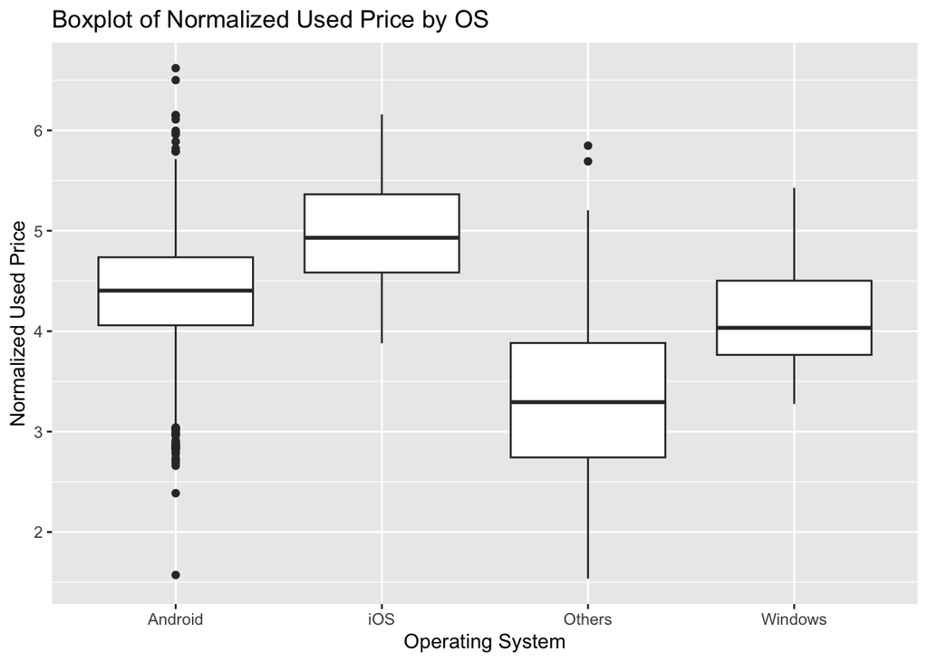

```r
set.seed(100)
# Read the data
trainData <- read.csv("used_device_data.csv")

# Creating a boxplot of normalized_used_price against os
ggplot(trainData, aes(x = os, y = normalized_used_price)) +
  geom_boxplot() +
  labs(title = "Boxplot of Normalized Used Price by OS", x = "Operating System", y = "Normalized Used Price")
```

**Answer:** In this boxplot we should look at several aspects:

Median Price(Center Line of Box): The median indicates the typical value of used devices for each OS.The higher the median, the higher the typical price for devices with that OS. In this plot, iOS devices have a higher median price compared to Android, Others, and Windows, which indicates that typically, iOS devices are more expensive on the used market.

Based on this, the OS with the highest median and possibly with the highest upper quartile and outliers typically would be considered the most expensive on average.

Conclusion: iOS devices are generally the most expensive in the used market according to the following dataset. They maintain higher median prices compared to other OS categories. This could be reflective of a higher initial price, perceived quality, or longer lifespan, which makes them retain more value even when used.

b). (6 pts) Using `trainData`, create a scatterplot matrix and a correlation table that includes the following continuous variables: `battery b) front_camera_mp c) weight` Does there appear to be multicollinearity among these three variables? Include your reasoning.

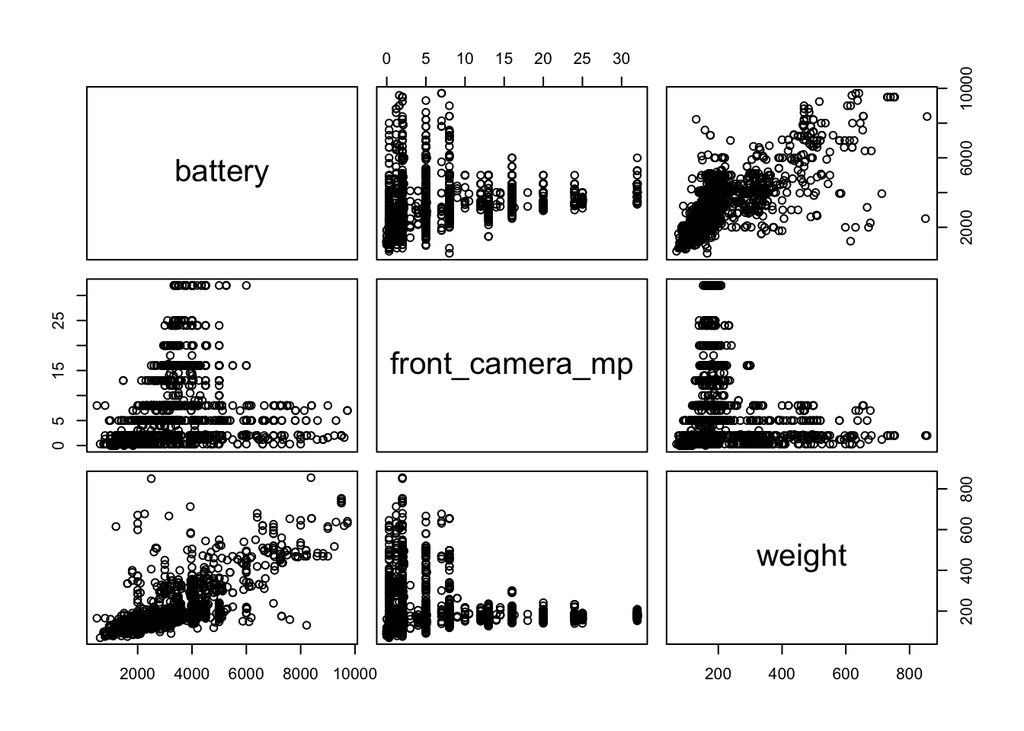

```r
set.seed(100)
# Plotting individual scatter plots
pairs(trainData[,c("battery", "front_camera_mp", "weight")])
```

```r
# Correlation table
cor(trainData[,c("battery", "front_camera_mp", "weight")])
```

```
##                   battery front_camera_mp      weight
## battery         1.0000000      0.34003702  0.71675693
## front_camera_mp 0.3400370      1.00000000 -0.01481554
## weight          0.7167569     -0.01481554  1.00000000
```

**Answer**: If we look for the correlation coefficients in the correlation matrix, a value close to ±1 indicates strong multi-collinearity. Values close to +1 or -1 indicate strong positive or negative correlation, respectively. High absolute values (e.g., greater than 0.7 or 0.8) suggest potential problems with multi-collinearity.

In the correlation between Battery and Weight, the correlation coefficient is approximately 0.717, which suggests a strong positive correlation. It is substantial enough to be cautious about multi-collinearity when both variables are included in the same regression model.

For the most part, Front Camera MP does not appear to contribute to multi-collinearity concerns based on its low correlations with both Battery(0.340) and Weight(-0.015).

## Part 2 [8 pts]: MULTIPLE LINEAR REGRESSION

a). (6 pts) Create a multiple regression model using “normalized_used_price” as the response variable and all the predictors. Call it model1. Display the summary of the `model`.

- Which coefficients are statistically significant at the significance level of 0.05?
- Interpret the estimated coefficient of days_used and osWindows in the context of the problem. Mention any assumptions you make about other predictors clearly when stating the interpretation.

```r
set.seed(100)
model1 <- lm(normalized_used_price ~ ., data = trainData)
summary(model1)
```

```
##
## Call:
## lm(formula = normalized_used_price ~ ., data = trainData)
##
## Residuals:
##     Min      1Q  Median      3Q     Max
## -1.4498 -0.1397  0.0248  0.1678  1.1339
##
## Coefficients:
##                          Estimate Std. Error t value Pr(>|t|)
## (Intercept)            -5.410e+01  7.899e+00  -6.849 8.90e-12 ***
## device_brandAlcatel    -2.678e-02  3.906e-02  -0.686  0.49291
## device_brandApple      -1.045e-02  1.434e-01  -0.073  0.94191
## device_brandAsus        4.239e-02  3.920e-02   1.081  0.27958
## device_brandBlackBerry  1.174e-01  6.636e-02   1.769  0.07694 .
## device_brandCelkon     -1.334e-01  5.423e-02  -2.461  0.01393 *
## device_brandCoolpad    -3.213e-03  6.303e-02  -0.051  0.95935
## device_brandGionee      1.886e-03  4.543e-02   0.042  0.96688
## device_brandGoogle      1.048e-02  7.312e-02   0.143  0.88602
## device_brandHonor       4.020e-03  4.025e-02   0.100  0.92044
## device_brandHTC        -1.099e-02  3.989e-02  -0.276  0.78295
## device_brandHuawei     -2.209e-02  3.645e-02  -0.606  0.54452
## device_brandKarbonn    -1.575e-02  5.457e-02  -0.289  0.77290
## device_brandLava        1.214e-02  5.201e-02   0.233  0.81546
## device_brandLenovo      1.478e-02  3.736e-02   0.396  0.69245
## device_brandLG         -3.466e-02  3.699e-02  -0.937  0.34876
## device_brandMeizu       6.666e-04  4.861e-02   0.014  0.98906
## device_brandMicromax   -3.243e-02  3.940e-02  -0.823  0.41057
## device_brandMicrosoft   6.112e-02  7.061e-02   0.866  0.38674
## device_brandMotorola   -4.798e-02  4.176e-02  -1.149  0.25064
## device_brandNokia       6.568e-02  4.248e-02   1.546  0.12216
## device_brandOnePlus     7.083e-03  1.094e-01   0.065  0.94837
## device_brandOppo        5.429e-03  4.039e-02   0.134  0.89310
## device_brandOthers     -2.006e-02  3.435e-02  -0.584  0.55928
## device_brandPanasonic   3.590e-03  4.795e-02   0.075  0.94033
## device_brandRealme      2.254e-01  1.095e-01   2.058  0.03969 *
## device_brandSamsung    -3.059e-02  3.534e-02  -0.866  0.38681
## device_brandSony       -7.591e-02  4.261e-02  -1.782  0.07491 .
## device_brandSpice      -2.286e-02  5.398e-02  -0.424  0.67192
## device_brandVivo       -4.385e-02  4.092e-02  -1.072  0.28402
```

[output cut: 9 more lines]

```
## rear_camera_mp          2.137e-02  1.279e-03  16.708  < 2e-16 ***
## front_camera_mp         1.352e-02  1.009e-03  13.395  < 2e-16 ***
## internal_memory         5.637e-05  5.376e-05   1.049  0.29443
## ram                     2.415e-02  4.718e-03   5.119 3.25e-07 ***
## battery                -1.709e-05  6.377e-06  -2.680  0.00740 **
## weight                  9.682e-04  1.093e-04   8.859  < 2e-16 ***
## release_year            2.745e-02  3.913e-03   7.014 2.81e-12 ***
## days_used               3.588e-05  2.603e-05   1.378  0.16817
## normalized_new_price    4.280e-01  1.054e-02  40.607  < 2e-16 ***
## ---
## Signif. codes:  0 '***' 0.001 '**' 0.01 '*' 0.05 '.' 0.1 ' ' 1
##
## Residual standard error: 0.2323 on 3205 degrees of freedom
## Multiple R-squared:  0.8416, Adjusted R-squared:  0.8392
## F-statistic: 362.2 on 47 and 3205 DF,  p-value: < 2.2e-16
```

**Answer**: According to the model, device_brandCelkon, device_brandRealme, device_brandXiaomi, osOthers, screen_size, X4gyes, rear_camera_mp, front_camera_mp, ram, battery, weight, release_year, normalized_new_price are statistically significant at the significance level of 0.05.

For days_used the coefficient (Estimate = 0.00003588) is not statistically significant (p-value = 0.16817), suggesting that the number of days a device has been used does not have a significant impact on its normalized used price within the context of this model. This might indicate that the effect of usage duration is minimal compared to other factors like technical specifications and brand.

osWindows: The coefficient (Estimate = -0.01713) also shows no significant impact (p-value = 0.65244), suggesting that having Windows as an OS, compared to the baseline OS (likely Android, if not otherwise specified), does not significantly alter the used price.

b). (2 pts) Check model1 for multicollinearity using variance inflation factor (vif). Is multicollinearity a problem.Explain your conclusion.

```r
set.seed(100)
vif(model1)
```

```
##                           GVIF Df GVIF^(1/(2*Df))
## device_brand         87.691614 32        1.072405
## os                   38.087096  3        1.834269
## screen_size           7.166472  1        2.677027
## X4g                   2.448284  1        1.564699
## X5g                   1.598347  1        1.264257
## rear_camera_mp        2.272491  1        1.507478
## front_camera_mp       2.673056  1        1.634948
## internal_memory       1.271110  1        1.127435
## ram                   2.015247  1        1.419594
## battery               4.122086  1        2.030292
## weight                5.875934  1        2.424033
## release_year          4.415708  1        2.101359
## days_used             2.262998  1        1.504327
## normalized_new_price  3.020174  1        1.737865
```

**Answer**: Values of VIF that exceed 10 are often regarded as indicating multi-collinearity. device_brand have a high VIF of 87.69 indicates significant multi-collinearity. This is expected as brand categories are likely to be highly correlated with each other and with other device features.

os also have VIF of 38.08 also suggests substantial multi-collinearity among different operating systems.

screen_size have a VIF of 7.17 suggests very less moderate multi-collinearity, which might be due to its relationship with other size-related features like weight.

This states that multi-collinearity is a problem

## Part 3 [30 pts]: VARIABLE SELECTION

1. (12 pts) Conduct bestsubset selection, forward, backward step-wise regression on model1 using AIC (assume no controlling variables), and all the selected model `model2, model3, and model4`, respectively. Display the summary of the model. Note: Do not forget to put “trace=F” in order to prevent long printed outputs.
- What is the AIC and BIC of the selected model?
- Which of the original variables are selected?

```
You may use different methods other than the ones we used on the class. For example, using step(), see https://www.rdocumentation.org/packages/stats/versions/3.6.2/topics/step
```

```r
set.seed(100)
library(leaps) # For best subset selection

# Best Subset Selection
model2 <- regsubsets(normalized_used_price ~ ., data = trainData, nvmax = 15)
summary(model2)
```

```
## Subset selection object
## Call: regsubsets.formula(normalized_used_price ~ ., data = trainData,
##     nvmax = 15)
## 47 Variables  (and intercept)
##                        Forced in Forced out
## device_brandAlcatel        FALSE      FALSE
## device_brandApple          FALSE      FALSE
## device_brandAsus           FALSE      FALSE
## device_brandBlackBerry     FALSE      FALSE
## device_brandCelkon         FALSE      FALSE
## device_brandCoolpad        FALSE      FALSE
## device_brandGionee         FALSE      FALSE
## device_brandGoogle         FALSE      FALSE
## device_brandHonor          FALSE      FALSE
## device_brandHTC            FALSE      FALSE
```

[output cut: 247 more lines]

```r
# Forward Stepwise Regression
model3 <- step(model1, direction = "forward", scope = formula(model1), trace = F)

# Backward Stepwise Regression
model4 <- step(model1, direction = "backward", trace = F)

# Display summary and AIC, BIC for selected models
summary(model3)  # model using forward stepwise
```

```
##
## Call:
## lm(formula = normalized_used_price ~ device_brand + os + screen_size +
##     X4g + X5g + rear_camera_mp + front_camera_mp + internal_memory +
##     ram + battery + weight + release_year + days_used + normalized_new_price,
##     data = trainData)
##
## Residuals:
##     Min      1Q  Median      3Q     Max
## -1.4498 -0.1397  0.0248  0.1678  1.1339
##
## Coefficients:
##                          Estimate Std. Error t value Pr(>|t|)
## (Intercept)            -5.410e+01  7.899e+00  -6.849 8.90e-12 ***
## device_brandAlcatel    -2.678e-02  3.906e-02  -0.686  0.49291
## device_brandApple      -1.045e-02  1.434e-01  -0.073  0.94191
## device_brandAsus        4.239e-02  3.920e-02   1.081  0.27958
## device_brandBlackBerry  1.174e-01  6.636e-02   1.769  0.07694 .
## device_brandCelkon     -1.334e-01  5.423e-02  -2.461  0.01393 *
## device_brandCoolpad    -3.213e-03  6.303e-02  -0.051  0.95935
## device_brandGionee      1.886e-03  4.543e-02   0.042  0.96688
## device_brandGoogle      1.048e-02  7.312e-02   0.143  0.88602
## device_brandHonor       4.020e-03  4.025e-02   0.100  0.92044
## device_brandHTC        -1.099e-02  3.989e-02  -0.276  0.78295
## device_brandHuawei     -2.209e-02  3.645e-02  -0.606  0.54452
## device_brandKarbonn    -1.575e-02  5.457e-02  -0.289  0.77290
## device_brandLava        1.214e-02  5.201e-02   0.233  0.81546
## device_brandLenovo      1.478e-02  3.736e-02   0.396  0.69245
## device_brandLG         -3.466e-02  3.699e-02  -0.937  0.34876
## device_brandMeizu       6.666e-04  4.861e-02   0.014  0.98906
## device_brandMicromax   -3.243e-02  3.940e-02  -0.823  0.41057
## device_brandMicrosoft   6.112e-02  7.061e-02   0.866  0.38674
## device_brandMotorola   -4.798e-02  4.176e-02  -1.149  0.25064
## device_brandNokia       6.568e-02  4.248e-02   1.546  0.12216
## device_brandOnePlus     7.083e-03  1.094e-01   0.065  0.94837
## device_brandOppo        5.429e-03  4.039e-02   0.134  0.89310
## device_brandOthers     -2.006e-02  3.435e-02  -0.584  0.55928
## device_brandPanasonic   3.590e-03  4.795e-02   0.075  0.94033
## device_brandRealme      2.254e-01  1.095e-01   2.058  0.03969 *
## device_brandSamsung    -3.059e-02  3.534e-02  -0.866  0.38681
```

[output cut: 12 more lines]

```
## rear_camera_mp          2.137e-02  1.279e-03  16.708  < 2e-16 ***
## front_camera_mp         1.352e-02  1.009e-03  13.395  < 2e-16 ***
## internal_memory         5.637e-05  5.376e-05   1.049  0.29443
## ram                     2.415e-02  4.718e-03   5.119 3.25e-07 ***
## battery                -1.709e-05  6.377e-06  -2.680  0.00740 **
## weight                  9.682e-04  1.093e-04   8.859  < 2e-16 ***
## release_year            2.745e-02  3.913e-03   7.014 2.81e-12 ***
## days_used               3.588e-05  2.603e-05   1.378  0.16817
## normalized_new_price    4.280e-01  1.054e-02  40.607  < 2e-16 ***
## ---
## Signif. codes:  0 '***' 0.001 '**' 0.01 '*' 0.05 '.' 0.1 ' ' 1
##
## Residual standard error: 0.2323 on 3205 degrees of freedom
## Multiple R-squared:  0.8416, Adjusted R-squared:  0.8392
## F-statistic: 362.2 on 47 and 3205 DF,  p-value: < 2.2e-16
```

```r
summary(model4)  # model using backward stepwise
```

```
##
## Call:
## lm(formula = normalized_used_price ~ device_brand + screen_size +
##     X4g + X5g + rear_camera_mp + front_camera_mp + ram + battery +
##     weight + release_year + days_used + normalized_new_price,
##     data = trainData)
##
## Residuals:
##      Min       1Q   Median       3Q      Max
## -1.43715 -0.13845  0.02388  0.16904  1.15219
##
## Coefficients:
##                          Estimate Std. Error t value Pr(>|t|)
## (Intercept)            -5.506e+01  7.842e+00  -7.022 2.66e-12 ***
## device_brandAlcatel    -2.770e-02  3.903e-02  -0.710  0.47792
## device_brandApple      -8.763e-02  5.113e-02  -1.714  0.08661 .
## device_brandAsus        4.435e-02  3.916e-02   1.132  0.25755
## device_brandBlackBerry  8.834e-02  6.455e-02   1.369  0.17122
## device_brandCelkon     -1.272e-01  5.329e-02  -2.387  0.01702 *
## device_brandCoolpad    -8.923e-04  6.303e-02  -0.014  0.98870
## device_brandGionee      5.276e-03  4.540e-02   0.116  0.90749
## device_brandGoogle      8.201e-03  7.312e-02   0.112  0.91070
## device_brandHonor       4.462e-03  4.024e-02   0.111  0.91171
## device_brandHTC        -1.012e-02  3.989e-02  -0.254  0.79967
## device_brandHuawei     -2.106e-02  3.643e-02  -0.578  0.56318
## device_brandKarbonn    -7.472e-03  5.443e-02  -0.137  0.89082
## device_brandLava        2.218e-02  5.175e-02   0.429  0.66827
## device_brandLenovo      1.726e-02  3.733e-02   0.462  0.64396
## device_brandLG         -3.407e-02  3.698e-02  -0.921  0.35693
## device_brandMeizu       1.756e-03  4.860e-02   0.036  0.97119
## device_brandMicromax   -2.938e-02  3.937e-02  -0.746  0.45552
## device_brandMicrosoft   4.756e-02  6.049e-02   0.786  0.43178
## device_brandMotorola   -4.523e-02  4.174e-02  -1.083  0.27869
## device_brandNokia       5.211e-02  4.140e-02   1.259  0.20820
## device_brandOnePlus     7.119e-03  1.094e-01   0.065  0.94811
## device_brandOppo        6.809e-03  4.039e-02   0.169  0.86614
## device_brandOthers     -1.890e-02  3.435e-02  -0.550  0.58220
## device_brandPanasonic   5.849e-03  4.793e-02   0.122  0.90289
## device_brandRealme      2.282e-01  1.095e-01   2.084  0.03726 *
## device_brandSamsung    -3.173e-02  3.532e-02  -0.898  0.36905
```

[output cut: 8 more lines]

```
## X5gyes                 -4.886e-02  3.178e-02  -1.537  0.12432
## rear_camera_mp          2.139e-02  1.267e-03  16.875  < 2e-16 ***
## front_camera_mp         1.343e-02  9.953e-04  13.492  < 2e-16 ***
## ram                     2.518e-02  4.545e-03   5.541 3.26e-08 ***
## battery                -1.803e-05  6.344e-06  -2.843  0.00450 **
## weight                  9.202e-04  1.066e-04   8.635  < 2e-16 ***
## release_year            2.791e-02  3.885e-03   7.184 8.39e-13 ***
## days_used               3.745e-05  2.597e-05   1.442  0.14939
## normalized_new_price    4.325e-01  1.027e-02  42.108  < 2e-16 ***
## ---
## Signif. codes:  0 '***' 0.001 '**' 0.01 '*' 0.05 '.' 0.1 ' ' 1
##
## Residual standard error: 0.2324 on 3209 degrees of freedom
## Multiple R-squared:  0.8413, Adjusted R-squared:  0.8392
## F-statistic: 395.6 on 43 and 3209 DF,  p-value: < 2.2e-16
```

```r
AIC(model3)
```

```
## [1] -215.1083
```

```r
BIC(model4)
```

```
## [1] 56.22553
```

```r
AIC(model3)
```

```
## [1] -215.1083
```

```r
BIC(model4)
```

```
## [1] 56.22553
```

b).(14 pts) Perform LASSO and RIDGE regression on the dataset “trainData” .Use `cv.glmnet()` to find the lambda value that minimizes the cross-validation error using 10 fold CV.

Answer the following questions for both models.

- State the value of the optimal lambda.
- Fit the model with 100 values for lambda.
- Extract coefficients at the optimal lambda. Which coefficients are selected? Compare the number of coefficients selected by both the models. Why are you seeing this behavior?
- Plot the coefficient path for both the models and compare.

```
 See https://www.science.smith.edu/~jcrouser/SDS293/labs/lab10-r.html

 Remember to use as.matrix() to process categorical predictors
```

```r
set.seed(100)
library(glmnet)
# Prepare the matrix format for glmnet
x <- model.matrix(normalized_used_price ~ ., data = trainData)[,-1]
y <- trainData$normalized_used_price

# LASSO and Ridge Regression using cross-validation
cv_fit_lasso <- cv.glmnet(x, y, alpha = 1, nfolds = 10)  # LASSO
cv_fit_ridge <- cv.glmnet(x, y, alpha = 0, nfolds = 10)  # Ridge

# Optimal lambda
lambda_lasso_opt <- cv_fit_lasso$lambda.min
lambda_ridge_opt <- cv_fit_ridge$lambda.min

print(lambda_lasso_opt)
```

```
## [1] 0.001139361
```

```r
print(lambda_ridge_opt)
```

```
## [1] 0.04818633
```

```r
# Coefficients at optimal lambda
coef(cv_fit_lasso, s = lambda_lasso_opt)
```

```
## 48 x 1 sparse Matrix of class "dgCMatrix"
##                                   s1
## (Intercept)            -4.954532e+01
## device_brandAlcatel    -4.881195e-03
## device_brandApple       .
## device_brandAsus        5.346301e-02
## device_brandBlackBerry  1.149849e-01
## device_brandCelkon     -1.080585e-01
## device_brandCoolpad     4.095851e-04
## device_brandGionee      6.325908e-03
## device_brandGoogle      1.110693e-02
## device_brandHonor       1.311036e-02
## device_brandHTC         3.253909e-05
## device_brandHuawei     -1.800187e-03
## device_brandKarbonn     .
## device_brandLava        1.607075e-02
## device_brandLenovo      2.524925e-02
## device_brandLG         -1.574463e-02
## device_brandMeizu       8.903933e-03
## device_brandMicromax   -1.196812e-02
## device_brandMicrosoft   4.781258e-02
## device_brandMotorola   -2.525643e-02
## device_brandNokia       6.859199e-02
## device_brandOnePlus     .
## device_brandOppo        1.619520e-02
## device_brandOthers     -1.089963e-03
## device_brandPanasonic   1.098852e-02
## device_brandRealme      2.110712e-01
## device_brandSamsung    -1.120563e-02
## device_brandSony       -5.114817e-02
## device_brandSpice       .
## device_brandVivo       -2.068079e-02
## device_brandXiaomi      8.916723e-02
## device_brandXOLO       -2.769251e-03
## device_brandZTE         .
## osiOS                  -5.623760e-02
## osOthers               -5.335348e-02
## osWindows               .
## screen_size             2.401877e-02
## X4gyes                  4.002128e-02
## X5gyes                 -2.935706e-02
## rear_camera_mp          2.121554e-02
## front_camera_mp         1.344894e-02
## internal_memory         3.217143e-05
## ram                     2.212052e-02
## battery                -8.768545e-06
## weight                  8.868534e-04
## release_year            2.519374e-02
## days_used               2.237379e-05
## normalized_new_price    4.266029e-01
```

```r
coef(cv_fit_ridge, s = lambda_ridge_opt)
```

```
## 48 x 1 sparse Matrix of class "dgCMatrix"
##                                   s1
## (Intercept)            -3.684743e+01
## device_brandAlcatel    -2.444145e-02
## device_brandApple       1.988907e-02
## device_brandAsus        5.193699e-02
## device_brandBlackBerry  1.252985e-01
## device_brandCelkon     -1.531483e-01
## device_brandCoolpad    -1.213474e-04
## device_brandGionee      9.222293e-03
## device_brandGoogle      5.517678e-02
## device_brandHonor       7.671735e-03
## device_brandHTC         1.144570e-02
## device_brandHuawei     -7.167276e-03
## device_brandKarbonn    -2.541887e-02
## device_brandLava       -6.692634e-03
## device_brandLenovo      1.376166e-02
## device_brandLG         -2.222030e-02
## device_brandMeizu       1.355316e-02
## device_brandMicromax   -4.862557e-02
## device_brandMicrosoft   4.916290e-02
## device_brandMotorola   -4.158765e-02
## device_brandNokia       7.116099e-02
## device_brandOnePlus     3.749004e-02
## device_brandOppo        2.823160e-02
## device_brandOthers     -1.087258e-02
## device_brandPanasonic   1.883308e-03
## device_brandRealme      1.888127e-01
## device_brandSamsung    -9.641616e-03
## device_brandSony       -5.065269e-02
## device_brandSpice      -4.665285e-02
## device_brandVivo       -1.936466e-02
## device_brandXiaomi      7.454283e-02
## device_brandXOLO       -2.864682e-02
## device_brandZTE        -8.546369e-03
## osiOS                  -3.580419e-02
## osOthers               -9.272563e-02
## osWindows              -9.395070e-03
## screen_size             2.297429e-02
## X4gyes                  6.114000e-02
## X5gyes                 -9.663336e-03
## rear_camera_mp          2.157775e-02
## front_camera_mp         1.329090e-02
## internal_memory         1.120094e-04
## ram                     3.002904e-02
## battery                 6.258307e-06
## weight                  8.098224e-04
## release_year            1.902631e-02
## days_used               1.176423e-05
## normalized_new_price    3.651500e-01
```

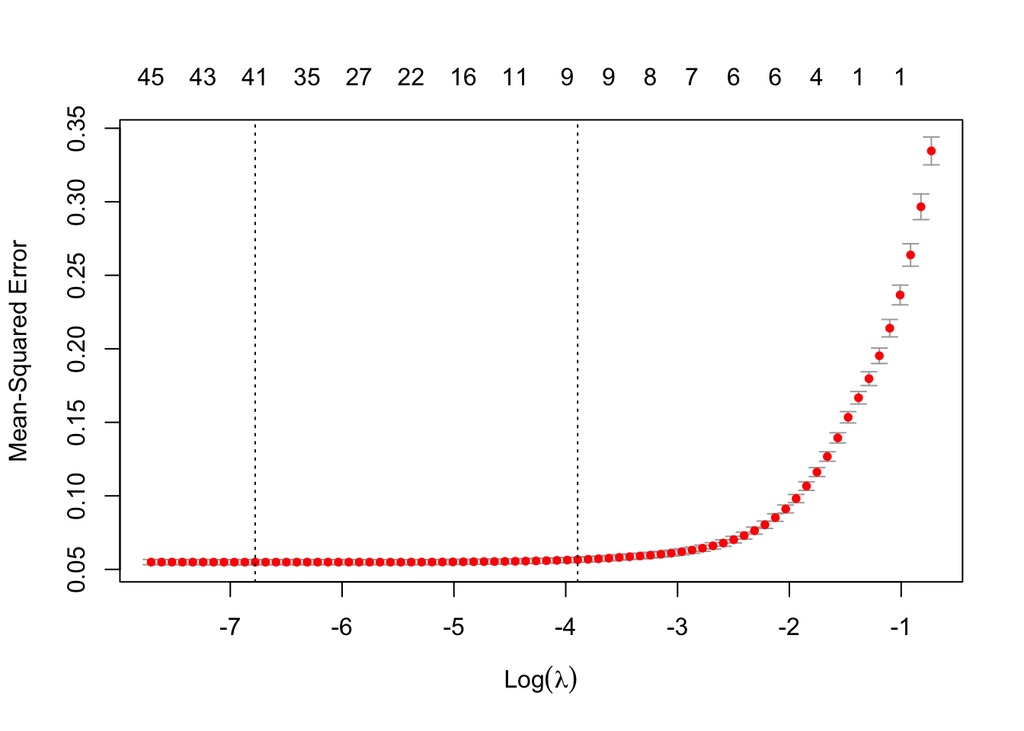

```r
# Plotting coefficient paths
plot(cv_fit_lasso)
```

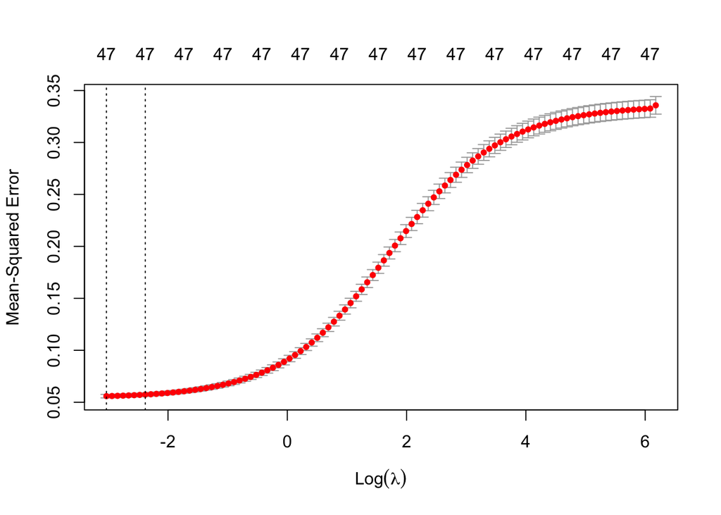

```r
plot(cv_fit_ridge)
```

c).(4 pts) Apply Principal Component Analysis and then create a regression model using the first few principal components, name it `pca_model`.

```
You can use the R function prcomp for PCA. (Note that to first scale the data, you can include scale. = TRUE to scale as part of the PCA function. Don’t forget that, to make a prediction for the new city, you’ll need to unscale the coefficients (i.e., do the scaling calculation in reverse)!)
```

```r
set.seed(100)
library(pls)
pca_model <- pcr(normalized_used_price ~ ., data = trainData, scale. = TRUE, validation = "CV")
summary(pca_model)
```

```
## Data:    X dimension: 3253 47
##  Y dimension: 3253 1
## Fit method: svdpc
## Number of components considered: 47
##
## VALIDATION: RMSEP
## Cross-validated using 10 random segments.
##        (Intercept)  1 comps  2 comps  3 comps  4 comps  5 comps  6 comps
## CV          0.5795   0.4594   0.4527   0.4512   0.4514   0.3431   0.3244
## adjCV       0.5795   0.4594   0.4527   0.4512   0.4514   0.3431   0.3243
##        7 comps  8 comps  9 comps  10 comps  11 comps  12 comps  13 comps
## CV      0.3126   0.3076   0.2975    0.2402    0.2382     0.238    0.2359
## adjCV   0.3126   0.3076   0.2974    0.2402    0.2381     0.238    0.2358
##        14 comps  15 comps  16 comps  17 comps  18 comps  19 comps  20 comps
## CV       0.2360    0.2351    0.2352    0.2352    0.2353    0.2353    0.2352
## adjCV    0.2359    0.2350    0.2351    0.2351    0.2352    0.2352    0.2351
##        21 comps  22 comps  23 comps  24 comps  25 comps  26 comps  27 comps
## CV       0.2351    0.2351    0.2350    0.2346    0.2346    0.2346    0.2347
## adjCV    0.2350    0.2351    0.2349    0.2345    0.2345    0.2345    0.2346
##        28 comps  29 comps  30 comps  31 comps  32 comps  33 comps  34 comps
## CV       0.2346    0.2345    0.2346    0.2347    0.2348    0.2347    0.2349
## adjCV    0.2345    0.2344    0.2344    0.2345    0.2346    0.2345    0.2347
##        35 comps  36 comps  37 comps  38 comps  39 comps  40 comps  41 comps
## CV       0.2349    0.2349    0.2348    0.2350    0.2354    0.2354    0.2352
## adjCV    0.2347    0.2347    0.2346    0.2348    0.2351    0.2352    0.2350
##        42 comps  43 comps  44 comps  45 comps  46 comps  47 comps
## CV       0.2353    0.2353    0.2354    0.2353    0.2353    0.2353
## adjCV    0.2350    0.2351    0.2351    0.2350    0.2351    0.2351
##
## TRAINING: % variance explained
##                        1 comps  2 comps  3 comps  4 comps  5 comps  6 comps
## X                        96.54    99.39    99.79   100.00   100.00   100.00
## normalized_used_price    37.27    39.10    39.54    39.64    65.03    68.83
##                        7 comps  8 comps  9 comps  10 comps  11 comps  12 comps
## X                       100.00   100.00   100.00    100.00    100.00     100.0
## normalized_used_price    71.06    72.01    73.86     82.99     83.29      83.3
##                        13 comps  14 comps  15 comps  16 comps  17 comps
## X                        100.00    100.00    100.00    100.00    100.00
## normalized_used_price     83.62     83.64     83.76     83.76     83.76
##                        18 comps  19 comps  20 comps  21 comps  22 comps
## X                        100.00    100.00    100.00    100.00    100.00
## normalized_used_price     83.78     83.79     83.79     83.83     83.83
##                        23 comps  24 comps  25 comps  26 comps  27 comps
## X                        100.00    100.00    100.00    100.00    100.00
## normalized_used_price     83.88     83.93     83.93     83.93     83.96
##                        28 comps  29 comps  30 comps  31 comps  32 comps
## X                        100.00    100.00    100.00    100.00    100.00
## normalized_used_price     83.99     84.02     84.02     84.02     84.05
##                        33 comps  34 comps  35 comps  36 comps  37 comps
## X                        100.00    100.00    100.00    100.00    100.00
## normalized_used_price     84.06     84.06     84.06     84.08     84.09
##                        38 comps  39 comps  40 comps  41 comps  42 comps
## X                         100.0     100.0     100.0    100.00    100.00
## normalized_used_price      84.1      84.1      84.1     84.12     84.12
##                        43 comps  44 comps  45 comps  46 comps  47 comps
## X                        100.00    100.00    100.00    100.00    100.00
## normalized_used_price     84.13     84.14     84.16     84.16     84.16
```

```r
coef(pca_model, ncomp = 5)
```

```
## , , 5 comps
##
##                        normalized_used_price
## device_brandAlcatel            -1.612541e-04
## device_brandApple              -3.394995e-05
## device_brandAsus               -3.400804e-05
## device_brandBlackBerry         -1.097275e-05
## device_brandCelkon             -8.417362e-05
## device_brandCoolpad             2.137732e-05
## device_brandGionee             -2.554371e-05
## device_brandGoogle             -4.055873e-06
## device_brandHonor               1.225031e-04
## device_brandHTC                 8.694624e-05
## device_brandHuawei              2.014643e-04
## device_brandKarbonn            -2.295006e-05
## device_brandLava               -5.117059e-05
## device_brandLenovo             -8.529230e-05
## device_brandLG                 -1.882481e-04
## device_brandMeizu               8.099628e-05
## device_brandMicromax           -1.529034e-04
## device_brandMicrosoft           1.250668e-06
## device_brandMotorola            5.040945e-05
## device_brandNokia              -1.266139e-04
## device_brandOnePlus             1.402974e-05
## device_brandOppo                2.249443e-04
## device_brandOthers             -2.259225e-04
## device_brandPanasonic           4.508556e-06
## device_brandRealme              6.859665e-06
## device_brandSamsung            -7.280731e-05
## device_brandSony                1.242707e-04
## device_brandSpice              -4.031270e-05
## device_brandVivo                2.402453e-04
## device_brandXiaomi              1.218368e-04
## device_brandXOLO               -4.373639e-05
## device_brandZTE                 9.628216e-05
## osiOS                          -2.243673e-05
## osOthers                       -3.416527e-04
## osWindows                      -8.505584e-06
## screen_size                     4.649742e-03
## X4gyes                          1.489429e-03
## X5gyes                          1.714143e-04
## rear_camera_mp                  2.570291e-02
## front_camera_mp                 4.477155e-02
## internal_memory                 2.441250e-05
## ram                             3.691454e-03
## battery                         8.072239e-05
## weight                          1.672304e-03
## release_year                    5.736056e-03
## days_used                       1.761435e-04
## normalized_new_price            2.679982e-03
```

## Part 4 [24 pts]: PREDICTION MODEL COMPARISON

a).(14 pts) Using the testData, use the following models to predict the normalized price of the devices:

- model1 (Part 2a)
- model2 (Part 3a)
- model3 (Part 3a)
- model4 (Part 3a)
- Lasso (Part 3b)
- Ridge (Part 3b)
- pca_model (Part 3c)

Show the first five predictions using each model along with their true values. Are the values different?

```r
# Predictions
predictions_model1 <- predict(model1, newdata = testData)
predictions_model2 <- model.matrix(normalized_used_price ~ ., data = testData)[,names(coef(model2, 15))]%*%coef(model2, 15)
predictions_model3 <- predict(model3, newdata = testData)
predictions_model4 <- predict(model4, newdata = testData)
predictions_lasso <- predict(cv_fit_lasso, s = "lambda.min", newx = model.matrix(normalized_used_price ~ ., data = testData)[,-1])
predictions_ridge <- predict(cv_fit_ridge, s = "lambda.min", newx = model.matrix(normalized_used_price ~ ., data = testData)[,-1])


predictions_pca <- predict(pca_model, newdata = testData)

# Combining first five predictions from each model
first_five <- data.frame(
  True = testData$normalized_used_price[1:5],
  Model1 = predictions_model1[1:5],
  Model2 = predictions_model2[1:5],
  Model3 = predictions_model3[1:5],
  Model4 = predictions_model4[1:5],
  Lasso = as.vector(predictions_lasso[1:5]),
  Ridge = as.vector(predictions_ridge[1:5]),
  PCA = predictions_pca[1:5]
)

print(first_five)
```

```
##          True   Model1   Model2   Model3   Model4    Lasso    Ridge      PCA
## 503  4.072440 4.184333 4.177629 4.184333 4.185152 4.182879 4.188440 4.152943
## 2035 5.361902 5.180480 5.155950 5.180480 5.182382 5.170453 5.132691 4.443635
## 3033 3.183870 3.526681 3.515467 3.526681 3.522407 3.521603 3.546864 3.832604
## 3052 3.764451 3.543134 3.584344 3.543134 3.594359 3.540371 3.531692 3.882385
## 2967 4.603969 4.515643 4.503427 4.515643 4.517315 4.509603 4.494492 4.319757
```

b). (10 pts) Compare the predictions using mean squared prediction error. Which model performed the best? Reasoning your answer and discussion your choice(s).

```r
set.seed(100)
# Calculating MSPE for each model
mspe_model1 <- mean((predictions_model1 - testData$normalized_used_price)^2)
mspe_model2 <- mean((predictions_model2 - testData$normalized_used_price)^2)
mspe_model3 <- mean((predictions_model3 - testData$normalized_used_price)^2)
mspe_model4 <- mean((predictions_model4 - testData$normalized_used_price)^2)
mspe_lasso <- mean((as.vector(predictions_lasso) - testData$normalized_used_price)^2)
mspe_ridge <- mean((as.vector(predictions_ridge) - testData$normalized_used_price)^2)
mspe_pca <- mean((predictions_pca - testData$normalized_used_price)^2)

# Print MSPEs
mspe_data <- data.frame(Model1 = mspe_model1, Model2 = mspe_model2, Model3 = mspe_model3, Model4 = mspe_model4, Lasso = mspe_lasso, Ridge = mspe_ridge, PCA = mspe_pca)
print(mspe_data)
```

```
##       Model1     Model2     Model3    Model4      Lasso      Ridge        PCA
## 1 0.05295276 0.05276662 0.05295276 0.0525348 0.05289193 0.05323808 0.06799507
```

**Answer**:The PCA-based model performs the worst among all the models with the highest MSPE. This might be due to the loss of information inherent in dimensionality reduction. When reducing the number of variables using PCA, some relevant predictive information might be lost, which affects the model’s predictive power. Model4 shows the lowest MSPE among all the models with a value of 0.0525348. A lower MSPE indicates that the model has a better fit and predicts more accurately on the test data.